# Studying Japanese Kanji

### By: Zachary Lin

## Introduction

In the Japanese Language there are three alphabets consisting of hiragana, katakana and kanji. Hiragana and Katakana refer to the number syllabaries used to represent sounds and both consist of 76 commonly used characters. For example, the hiragana character 'あ' makes an 'a' sound and the katakana character 'タ' makes a 'ta' sound. More information about Hiragana and Katakana can be found [here](https://en.wikipedia.org/wiki/Kana). Next comes Kanji which is often one of the most daunting aspects of learning Japanese. Kanji characters are logographic characters that represent readings with each character typically having two or more readings that can be used across many different words. For example, the kanji character '行' is used in:  
行く ({い}く・{i}ku) meaning 'to go'  
行う ({おこな}う・{okona}u) meaning 'to do'  
行列 ({ぎょう}れつ・{gyou}retsu) meaning 'line'  
行動 ({こう}どう・{kou}dou) meaning 'behavior/conduct'  
Among many others.  
The specific reading of '行' appears in braces. It is estimated that the average Japanese person knows upwards of 4,000 kanji characters.

Buy why even use Kanji? Can we not just replace all the kanji with their readings so that people do not have to learn thousands of characters? However, becaue Japanese does not use spaces between words, kanji is essential for visual clarity and being able to quickly and easily identify the componenets of a sentence. By replacing all kanji with their readings, you can end up with sentences that look like:  
にわにはにわにわとりがいる (niwaniwaniwaniwatorigairu) (There are two chickens in the garden), which is extremely difficult to read.  
However, when using kanji, the sentence becomes:  
庭には二羽鶏がいる, which is a lot more comprensible as the individual components can be easily identified and read.  
Another important aspect of kanji is that it helps differietiate between homonymns. For example:  
髪 (かみ・kami) (hair)  
神 (かみ・kami) (god)  
紙 (かみ・kami) (paper)  
All three of these words are pronounced the same*, but are represented by different kanji characters.* (disregarding pitch accent)  
More information about kanji can be found [here](https://en.wikipedia.org/wiki/Kanji).

As kanji is essential to Japanese, where does one even begin learning it? There are thousands of resources, each with their own kanji lists all presented in different manners and sequences. Some order thier lists by character complexity, some by the grade level and some seemlingly randomly. The aim of this tutorial is to order kanji by frequency as used in a list containing rougly 10,000 commonly used words in Japanese. We will find which kanji are used in the most words and have the most occurances and are thus the most important to learn first. Kanji that appear in less words and have less occurrances, while still important to learn, are less of a priority. Finally, we will attempt to predict comprehension based on how many kanji someone knows, assuming they know all the related vocab the kanji is used in and the grammar of the sentence.

## Step 1: Data Collection

#### Downloading and Preprocessing the Data

First we need to download the Core10k Vocab Words from a shared Excel spreadsheet, located on Google Drive [here](https://drive.google.com/file/d/1HEdf46vx_TxgGod82gWMapRDE6jZipVB/view?usp=sharing).  
This spreadsheet lists roughly 10,000 commonly used words in Japanese.  
The Excel Spreadsheet can be downloaded and then re-saved as a UTF-8 CSV file.  
This will allow the Japanese characters to be read by the Juypter Notebook.  
Now we just need to import pandas and read the csv file.

```python
import pandas
rawdata = pandas.read_csv('Core10k.csv')
rawdata
```

|  | Vocab-Japanese | Vocab-Kana | Binary-Pitch-Classification | Vocab-English | Part of Speech | Sentence-English | Sentence-Japanese | Vocab-Furigana | Sentence-Furigana | Vocab-Clozed | ... | Vocab-structure | vocab freq | Notes-Production | Notes-Recognition | Vocab-RTK | Opt 2k Index | Opt index | Old Opt Sort | JLPT | Unnamed: 28 |
| --- | --- | --- | --- | --- | --- | --- | --- | --- | --- | --- | --- | --- | --- | --- | --- | --- | --- | --- | --- | --- | --- |
| 0 | これ | これ | 0 | this, this one | pronoun | I'll have this please. | これをください。 | これ | <b>これ</b>をください。 | これ | ... | h | 42.0 | NaN | NaN | NaN | 4 | 10.0 | 1 | NaN | NaN |
| 1 | 一つ | ひとつ | 2 | one (thing) | noun | Please give me one of those. | それを一つください。 | 一[ひと]つ | それを<b> 一[ひと]つ</b>ください。 | 一[ひと]つ | ... | 1kh | 232.0 | NaN | NaN | one | 1 | 2.0 | 2 | NaN | NaN |
| 2 | 一 | いち | 2 | one | noun | Let's start from scratch. | 一から始めましょう。 | 一[いち] | <b>一[いち]</b>から 始[はじ]めましょう。 | 一[いち] | ... | 1k | 62.0 | NaN | NaN | one | 2 | 3.0 | 3 | NaN | NaN |
| 3 | 二 | に | 1 | two | noun | I met that person twice. | その人には二回会った。 | 二[に] | その 人[ひと]には<b> 二[に]</b> 回[かい] 会[あ]った。 | 二[に] | ... | 1k | 103.0 | NaN | NaN | two | 5 | 4.0 | 4 | NaN | NaN |
| 4 | 二つ | ふたつ | 3, 0 | two (things) | noun | Can I get two ice cream cones? | ソフトクリームを二つください。 | 二[ふた]つ | ソフトクリームを<b> 二[ふた]つ</b>ください。 | 二[ふた]つ | ... | 1kh | 1275.0 | NaN | NaN | two | 6 | 5.0 | 5 | NaN | NaN |
| ... | ... | ... | ... | ... | ... | ... | ... | ... | ... | ... | ... | ... | ... | ... | ... | ... | ... | ... | ... | ... | ... |
| 9562 | 銜える | くわえる | 0 | grasp in the mouth | NaN | The bird was flying with a twig in its mouth. | 鳥が小枝をくわえて飛んでいった。 | 銜える[くわえる] | 鳥[とり]が 小[こ] 枝[えだ]を<b>くわえて</b> 飛[と]んでいった。 | くわえて | ... | 1kh | 11225.0 | NaN | NaN | NaN | 9564 | NaN | 9563 | NaN | NaN |
| 9563 | 餡こ | あんこ | 1 | anko; red bean jam | NaN | I ate a cake containing anko. | あんこの入ったお菓子を食べました。 | 餡こ[あんこ] | <b>あんこ</b>の 入[はい]ったお 菓子[かし]を 食[た]べました。 | あんこ | ... | 1kh | 56360.0 | NaN | NaN | NaN | 9565 | NaN | 9564 | NaN | NaN |
| 9564 | 飢饉 | ききん | 2, 1 | famine | NaN | The famine is a serious problem in that country. | その国では飢饉は深刻な問題だ。 | 飢饉[ききん] | その 国[くに]では<b> 飢饉[ききん]</b>は 深刻[しんこく]な 問題[もんだい]だ。 | 飢饉[ききん] | ... | 2k | 29662.0 | NaN | NaN | hungry | 9219 | NaN | 9565 | 2.0 | NaN |
| 9565 | 靡く | なびく | 2 | flutter | NaN | The flag is fluttering in the breeze. | 旗が風になびいている。 | 靡く[なびく] | 旗[はた]が 風[かぜ]に<b>なびいて</b>いる。 | なびいて | ... | 1kh | 17118.0 | NaN | NaN | NaN | 9566 | NaN | 9566 | NaN | NaN |
| 9566 | 黴 | かび | 0 | mold; mould | NaN | The bread is moldy. | パンにかびが生えています。 | 黴[かび] | パンに<b>かび</b>が 生[は]えています。 | かび | ... | 1k | 22168.0 | NaN | NaN | NaN | 9567 | NaN | 9567 | NaN | NaN |

9567 rows × 29 columns

## Step 2: Tidying the Data

However, this raw csv file contains a lot of information that is not needed. For the purpose of this tutorial, we only need the vocab columns and the sentence columns. As such, we will create a new dataframe that only contains these columns.

```python
#TIDY UP THE DATA
tidydata = pandas.DataFrame(columns = ['Vocab-Japanese', 'Vocab-Kana', 'Vocab-Furigana', 'Vocab-English','Sentence-Japanese', 'Sentence-English'])
tidydata['Vocab-Japanese'] = rawdata['Vocab-Japanese']
tidydata['Vocab-Kana'] = rawdata['Vocab-Kana']
tidydata['Vocab-Furigana'] = rawdata['Vocab-Furigana']
tidydata['Vocab-English'] = rawdata['Vocab-English']
tidydata['Sentence-Japanese'] = rawdata['Sentence-Japanese']
tidydata['Sentence-English'] = rawdata['Sentence-English']
tidydata
```

|  | Vocab-Japanese | Vocab-Kana | Vocab-Furigana | Vocab-English | Sentence-Japanese | Sentence-English |
| --- | --- | --- | --- | --- | --- | --- |
| 0 | これ | これ | これ | this, this one | これをください。 | I'll have this please. |
| 1 | 一つ | ひとつ | 一[ひと]つ | one (thing) | それを一つください。 | Please give me one of those. |
| 2 | 一 | いち | 一[いち] | one | 一から始めましょう。 | Let's start from scratch. |
| 3 | 二 | に | 二[に] | two | その人には二回会った。 | I met that person twice. |
| 4 | 二つ | ふたつ | 二[ふた]つ | two (things) | ソフトクリームを二つください。 | Can I get two ice cream cones? |
| ... | ... | ... | ... | ... | ... | ... |
| 9562 | 銜える | くわえる | 銜える[くわえる] | grasp in the mouth | 鳥が小枝をくわえて飛んでいった。 | The bird was flying with a twig in its mouth. |
| 9563 | 餡こ | あんこ | 餡こ[あんこ] | anko; red bean jam | あんこの入ったお菓子を食べました。 | I ate a cake containing anko. |
| 9564 | 飢饉 | ききん | 飢饉[ききん] | famine | その国では飢饉は深刻な問題だ。 | The famine is a serious problem in that country. |
| 9565 | 靡く | なびく | 靡く[なびく] | flutter | 旗が風になびいている。 | The flag is fluttering in the breeze. |
| 9566 | 黴 | かび | 黴[かび] | mold; mould | パンにかびが生えています。 | The bread is moldy. |

9567 rows × 6 columns

We now have a tidy data set with no missiing values to begin doing some data analysis on.

## Step 3: Data Analysis

The goal of our data analysis is to figure out which kanji characters have the most occurances and are used in the most words and are thus the most important characters to learn first. Lets begin by getting the total number of occurances of each character appears in our data set. We only want to count kanji characters so we will be skipping over the hiragana and katakana characters.

```python
#GET OCCURANCES OF EACH KANJI CHARACTER
allwords = ""
#omit hiragana, katakana characters and punctuation.
kana = "\n ぁ あ ぃ い ぅ う ぇ え ぉ お か が き ぎ く ぐ け げ こ ご さ ざ し じ す ず せ ぜ そ ぞ た だ ち ぢ っ つ づ て で と ど な に ぬ ね の は ば ぱ ひ び ぴ ふ ぶ ぷ へ べ ぺ ほ ぼ ぽ ま み む め も ゃ や ゅ ゆ ょ よ ら り る れ ろ ゎ わ ゐ ゑ を ん ゔ ゕ ゖ ァ ア ィ イ ゥ ウ ェ エ ォ オ カ ガ キ ギ ク グ ケ ゲ コ ゴ サ ザ シ ジ ス ズ セ ゼ ソ ゾ タ ダ チ ヂ ッ ツ ヅ テ デ ト ド ナ ニ ヌ ネ ノ ハ バ パ ヒ ビ ピ フ ブ プ ヘ ベ ペ ホ ボ ポ マ ミ ム メ モ ャ ヤ ュ ユ ョ ヨ ラ リ ル レ ロ ヮ ワ ヰ ヱ ヲ ン ヴ ヵ ヶ ヷ ヸ ヹ ヺ ・ ー ヽ ヾ 「　」"
for x,y in tidydata.iterrows():
    word = y["Vocab-Japanese"]
    kanji = ""
    for z in word:
        if z in kana:
            continue
        else:
            kanji = kanji + z
    allwords = allwords + kanji

listcount = pandas.Series(list(allwords)).value_counts()
listcount
```

```
日    108
人    102
大     93
見     82
気     80
    ...
鯨      1
穀      1
宙      1
宇      1
黴      1
Length: 2099, dtype: int64
```

We now have a list that shows each character and the total number of occurances of that character. But what does this tell us? We can see that "日" appears 108 times, which is the most out of any other character, but is 108 a signfigicant amount in the larger picture? 108 occurances among roughly 10,000 words seems pretty low. Lets calculate some totals so we can begin to put things into perspective.

```python
#GET TOTAL OCCURANCES OF ALL KANJI CHARACTERS
total = 0
for x in listcount:
    total = total + x
print("Total Occurances of Kanji Characters: " + str(total))
#GET TOTAL OCCURANCES OF UNIQUE KANJI CHARACTERS
print("Total Occurances of Unique Kanji Characters: " + str(listcount.size))
#GET TOTAL NUMBER OF WORDS THAT USE KANJI
charlist = []
totalwordcount = 0
#for every kanji character in the Core10k List
for x in range(2099):
    currchar = listcount.index[x]
    charlist.append(currchar)
#if a word contains at least 1 of these characters, add 1 to count
for a,b in tidydata.iterrows():
    for z in charlist:
        if z in b['Vocab-Japanese']:
            totalwordcount = totalwordcount + 1
            break
print("Total Number of Words that have at least 1 Kanji character: " + str(totalwordcount))
```

```
Total Occurances of Kanji Characters: 14813
Total Occurances of Unique Kanji Characters: 2099
Total Number of Words that have at least 1 Kanji character: 8347
```

After calulating our totals we can now see that "日" makes up 108 of 14813 occurances (.7291%) while only accounting for 1/2099 unique characters (.04%).  
"日" also appears in roughly 108 of 8347 words (1.2939%), assuming each occurnace appears in a different word, which is not always the case. See 日曜日 (にちようび・Sunday) which contains "日" twice in one word.  
Lets caculate these percents for all 2099 unique kanji in steps of 100. That is, the each step of 100 kanji have X occurances and appear in Y words while accounting for 100/2099 unique characters. We will also do these calculations in a way that does not double count words by simply checking if a word contains at least 1 kanji from the current step.

Starting with Percent Total Occurances:  
We will iteriatve over our list of kanji characters, adding together the counts in steps of 100.  
This data will be stored in a dataframe showing the total occurances and percent total occurances for each step. Percent total occurances will be caculated by taking the total occurances of the step divided by the overall total count of 14813.  
Finally, we will import matplotlib.pyplot in order to create a line graph showing step vs percent total occurances.

```python
#HOW MANY OCCURANCES OF KANJI IN STEPS OF 100
topX = [100, 200, 300, 400, 500, 600, 700, 800, 900, 1000, 1100, 1200, 1300, 1400, 1500, 1600, 1700, 1800, 1900, 2000, 2098]
occurancelist = []
occurancelistraw = []
curroccurances = 0
counter = 0
flag = 0
#for every step
for x in range(len(topX)):
    curroccurances = 0
    if flag == 0:
        #get kanji in that step and add occurances
        for y in range(topX[counter]+1):
            curroccurances = curroccurances + listcount[y]
        occurancelist.append((curroccurances/total)*100)
        occurancelistraw.append(curroccurances)
        counter = counter + 1
        flag = 1
    else:
        #get kanji in that step and add occurances
        for y in range(topX[counter-1] + 1, topX[counter] + 1):
            curroccurances = curroccurances + listcount[y]
        occurancelist.append((curroccurances/total)*100)
        occurancelistraw.append(curroccurances)
        counter = counter + 1

#make dataframe showing step, percent total occurances and total occurances
occcounttable = pandas.DataFrame(columns = ['Step', 'Percent Total Occurances', 'Total Occurances'])
steparray = ['1-100', '101-200', '201-300', '301-400', '401-500', '501-600', '601-700', '701-800', '801-900', '901-1000', '1001-1100', '1101-1200', '1201-1300', '1301-1400', '1401-1500', '1501-1600', '1601-1700', '1701-1800', '1801-1900', '1901-2000', '2001-2098']
for x in range(len(occurancelist)):
    occcounttable.at[x, 'Step'] = steparray[x]
    occcounttable.at[x, 'Percent Total Occurances'] = occurancelist[x]
    occcounttable.at[x, 'Total Occurances'] = occurancelistraw[x]
occcounttable
```

|  | Step | Percent Total Occurances | Total Occurances |
| --- | --- | --- | --- |
| 0 | 1-100 | 30.149193 | 4466 |
| 1 | 101-200 | 14.028218 | 2078 |
| 2 | 201-300 | 9.984473 | 1479 |
| 3 | 301-400 | 7.662189 | 1135 |
| 4 | 401-500 | 6.345777 | 940 |
| 5 | 501-600 | 5.30615 | 786 |
| 6 | 601-700 | 4.462297 | 661 |
| 7 | 701-800 | 3.733207 | 553 |
| 8 | 801-900 | 3.18639 | 472 |
| 9 | 901-1000 | 2.700331 | 400 |
| 10 | 1001-1100 | 2.059002 | 305 |
| 11 | 1101-1200 | 2.025248 | 300 |
| 12 | 1201-1300 | 1.491933 | 221 |
| 13 | 1301-1400 | 1.350165 | 200 |
| 14 | 1401-1500 | 1.350165 | 200 |
| 15 | 1501-1600 | 0.803348 | 119 |
| 16 | 1601-1700 | 0.675083 | 100 |
| 17 | 1701-1800 | 0.675083 | 100 |
| 18 | 1801-1900 | 0.675083 | 100 |
| 19 | 1901-2000 | 0.675083 | 100 |
| 20 | 2001-2098 | 0.661581 | 98 |

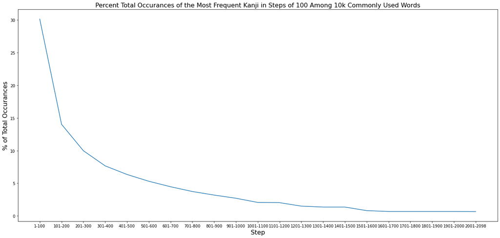

```python
#MAKE GRAPH OF TOTAL OCCURANCES
import matplotlib.pyplot as graph
graph.figure(figsize=(22,10))
graph.title('Percent Total Occurances of the Most Frequent Kanji in Steps of 100 Among 10k Commonly Used Words', fontsize = 16)
graph.xlabel('Step', fontsize = 16)
graph.ylabel('% of Total Occurances', fontsize = 16)
graph.plot(occcounttable['Step'], occcounttable['Percent Total Occurances'])
```

Now lets do Percent Word Count:  
For each step of 100, we will create a temporary list containing those 100 kanji.  
We will iterate over the Core10k dataset, counting the number of words that contain at least 1 character from the current step.  
The percent word count and total word count will be stored in a dataframe. These percents will add up to over 100% as a word that contains kanji from two different steps will be included in both of those counts. However, words that contain 2 kanji from the same step will not be counted twice.  
We can then create another line graph showing step vs percent word count.

```python
#HOW MANY WORDS CONTAIN AT LEAST 1 KANJI, IN STEPS OF 100 (FIRST 100, SECOND 100, NOT CUMULATIVE)
topX = [100, 200, 300, 400, 500, 600, 700, 800, 900, 1000, 1100, 1200, 1300, 1400, 1500, 1600, 1700, 1800, 1900, 2000, 2098]
wordcount = []
wordcountraw = []
counter = 0
charcounter = 0
flag = 0
#for each step
for x in range(len(topX)):
    charcounter = 0
    currcharlist = []
    if flag == 0:
        #get kanji in that step
        for y in range(topX[counter]+1):
            currchar = listcount.index[y]
            currcharlist.append(currchar)
        #for each word, if it contains at least one kanji from the current step, add 1 to count
        for a,b in tidydata.iterrows():
            for z in currcharlist:
                if z in b['Vocab-Japanese']:
                    charcounter = charcounter + 1
                    break
        wordcount.append((charcounter/totalwordcount)*100)
        wordcountraw.append(charcounter)
        counter = counter + 1
        flag = 1
    else:
        #get kanji in the step
        for y in range(topX[counter-1] + 1, topX[counter] + 1):
            currchar = listcount.index[y]
            currcharlist.append(currchar)
        #for each word, if it contains at least one kanji from the current step, add 1 to count
        for a,b in tidydata.iterrows():
            for z in currcharlist:
                if z in b['Vocab-Japanese']:
                    charcounter = charcounter + 1
                    break
        wordcount.append((charcounter/totalwordcount)*100)
        wordcountraw.append(charcounter)
        counter = counter + 1

#make a dataframe showing step, percent words used in and total words used in
wordcounttable = pandas.DataFrame(columns = ['Step', 'Percent of Words Used In', 'Total Words Used In'])
steparray = ['1-100', '101-200', '201-300', '301-400', '401-500', '501-600', '601-700', '701-800', '801-900', '901-1000', '1001-1100', '1101-1200', '1201-1300', '1301-1400', '1401-1500', '1501-1600', '1601-1700', '1701-1800', '1801-1900', '1901-2000', '2001-2098']
for x in range(len(wordcount)):
    wordcounttable.at[x, 'Step'] = steparray[x]
    wordcounttable.at[x, 'Percent of Words Used In'] = wordcount[x]
    wordcounttable.at[x, 'Total Words Used In'] = wordcountraw[x]
wordcounttable
```

|  | Step | Percent of Words Used In | Total Words Used In |
| --- | --- | --- | --- |
| 0 | 1-100 | 43.800168 | 3656 |
| 1 | 101-200 | 23.421589 | 1955 |
| 2 | 201-300 | 16.67665 | 1392 |
| 3 | 301-400 | 13.130466 | 1096 |
| 4 | 401-500 | 10.782317 | 900 |
| 5 | 501-600 | 9.248832 | 772 |
| 6 | 601-700 | 7.799209 | 651 |
| 7 | 701-800 | 6.45741 | 539 |
| 8 | 801-900 | 5.570864 | 465 |
| 9 | 901-1000 | 4.696298 | 392 |
| 10 | 1001-1100 | 3.606086 | 301 |
| 11 | 1101-1200 | 3.558165 | 297 |
| 12 | 1201-1300 | 2.599736 | 217 |
| 13 | 1301-1400 | 2.39607 | 200 |
| 14 | 1401-1500 | 2.38409 | 199 |
| 15 | 1501-1600 | 1.389721 | 116 |
| 16 | 1601-1700 | 1.078232 | 90 |
| 17 | 1701-1800 | 1.138133 | 95 |
| 18 | 1801-1900 | 1.102192 | 92 |
| 19 | 1901-2000 | 1.174075 | 98 |
| 20 | 2001-2098 | 1.150114 | 96 |

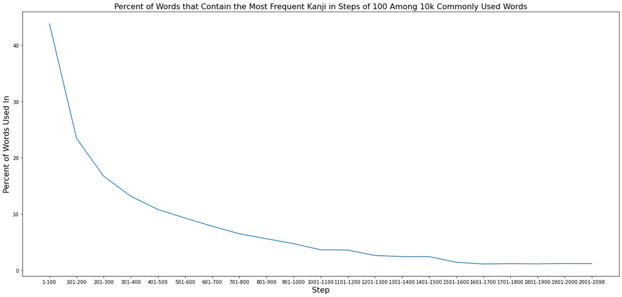

```python
#MAKE GRAPH OF WORD COUNT
import matplotlib.pyplot as graph
graph.figure(figsize=(22,10))
graph.title('Percent of Words that Contain the Most Frequent Kanji in Steps of 100 Among 10k Commonly Used Words', fontsize = 16)
graph.xlabel('Step', fontsize = 16)
graph.ylabel('Percent of Words Used In', fontsize = 16)
graph.plot(wordcounttable['Step'], wordcounttable['Percent of Words Used In'])
```

In the graph above, we can see that the first step of 100 kanji appear in ~43.8% of the total words that contain kanji (3656/8347). Similar to the occurances graph, each following step shows a decrease in percent word count. Step 101-200 appear in ~23.42% of the total words (1955/8347). Step 201-300 in ~16.67 of the total words (1392/8347).  
However, unlike the occurances graph, the word count graph sometimes shows an increase in word count. See step 1601-1700 and step 1701-1800. The former has a word count of 90 and the latter a word count of 95. From the occurances table, we can see that both of these steps consist of 100 kanji with 1 occurance each meaning that for this to occur, some of kanji in the step only appear together in the same word. Depending on how many times this happens, the word count will flucuate slightly.

From our two graphs, we can see the clear importance of learning the most frequent kanji first as you will encounter them the most often. Whearas, less frequent kanji are less of a priority to learn and often only appear in one word and slight variations of that word.

## Hypothesis Testing

So what is the point of learning the less frequent kanji that only appear in only a few or sometimes even just one word?  
In this section, we will predict comprehension based on how many kanji characters someone knows, assuming knowing the kanji character means you know all the related vocab and grammar. As such, this will be a gross oversimplification of actual comprehension, but will still serve the purpose of showing the importance of learning even the less frequent kanji.

In order to begin, we first must gather some data to which we can compare our kanji steps to. We will gathering the contents from a variety of different sources.  
We will be using:  
2 news articles from [News Web Easy](https://www3.nhk.or.jp/news/easy/). This sites provides short summaries of news articles which are often simplified for people learning Japanese.  
2 news articles from [News Web](https://www3.nhk.or.jp/news/). This site provides news articles that are not simplified or shortened.  
2 anime episodes from [animelon](https://animelon.com/). Episode transciptions are readily avialable when loading an episode.  
2 pop-songs. Full song lyrics are automatically displayed on google when searching "Name" + lyrics.  
And the privacy/copyright/trademark sections from the terms of use from [JP Amazon](https://www.amazon.co.jp/gp/help/customer/display.html/ref=ap_desktop_footer_cou?ie=UTF8&nodeId=643006).  
All of these sources contain text that can be easily copy + pasted and provide a decent range of difficulty.  
If you wish to recreate this data exactly, links to each exact source used will be linked at the end of this tutorial.

We will copy and paste the contents of each source into an excel file which will be saved as a UTF-8 CSV. The contents of which are displayed below.

```python
import pandas
comparedata = pandas.read_csv('SourceData.csv')
comparedata
```

|  | Content | Type |
| --- | --- | --- |
| 0 | 75歳以上の車の免許 違反がある人は運転技術の検査が必要. お年寄りが運転する車の事故をなく... | News Easy |
| 1 | 「早く外国人が日本に旅行できるようにしてほしい」. 新型コロナウイルスの問題で、政府は今、外... | News Easy |
| 2 | ウクライナ東部一帯で激しい攻防続く 米国防相が即時停戦要求。 ロシア軍はウクライナ東部2州の... | News |
| 3 | 神奈川県中心に約7万戸停電も復旧 地中の送電線故障が原因か。 13日夜遅く、横浜市青葉区など... | News |
| 4 | 暖かいね\nほんまやねえ\n秋にしてはいい買い物したわ\nだろう\n犬山さん、こんな感じかな... | Anime |
| 5 | 厚生労働省はニートや引きこもり層の改善のため特別予算を計上しました\nいや俺ももう上がる…か... | Anime |
| 6 | One day 雨が降る日も聞こえていたんだ\n私を呼ぶ声が\nどんな時も私のそばに居てくれ... | Lyrics |
| 7 | 人の幸せのために\n授かった名前と歌は\n一つの使命\nもしも全ての出会いの\n結晶が命のあ... | Lyrics |
| 8 | Amazon.co.jp へようこそ.米国の法人であるAmazon.com Services... | Amazon |

Now that we have some Japanese sentence data, lets predict how much someone will understand in cumulative steps of 500 kanji. That is how many kanji someone will recongize if they know 500, 1000, 1500 and 2098 kanji.  
First we must calculate how many kanji are in each of our sources. For each source we will get the total occurances of kanji, not counting any other characters including numbers, english, and punctuation.

```python
#GET OCCURANCES OF EACH KANJI CHARACTER PER SOURCE
current = ""
#do not count hiragana, katakana, english, numbers and punctuation
kanjicounttable = pandas.DataFrame(columns = ['Total Kanji Occurences'])
kana = "\n ぁ あ ぃ い ぅ う ぇ え ぉ お か が き ぎ く ぐ け げ こ ご さ ざ し じ す ず せ ぜ そ ぞ た だ ち ぢ っ つ づ て で と ど な に ぬ ね の は ば ぱ ひ び ぴ ふ ぶ ぷ へ べ ぺ ほ ぼ ぽ ま み む め も ゃ や ゅ ゆ ょ よ ら り る れ ろ ゎ わ ゐ ゑ を ん ゔ ゕ ゖ ァ ア ィ イ ゥ ウ ェ エ ォ オ カ ガ キ ギ ク グ ケ ゲ コ ゴ サ ザ シ ジ ス ズ セ ゼ ソ ゾ タ ダ チ ヂ ッ ツ ヅ テ デ ト ド ナ ニ ヌ ネ ノ ハ バ パ ヒ ビ ピ フ ブ プ ヘ ベ ペ ホ ボ ポ マ ミ ム メ モ ャ ヤ ュ ユ ョ ヨ ラ リ ル レ ロ ヮ ワ ヰ ヱ ヲ ン ヴ ヵ ヶ ヷ ヸ ヹ ヺ ・ ー ヽ ヾ A a B b C c D d E e F f G g H h I i J j K k L l M m N n O o P p Q q R r S s T t U u V v W w X x Y y Z z . 「　」1 2 3 4 5 6 7 8 9 0 \ / ? !"
#for each row, get total count of kanji used
for x,y in comparedata.iterrows():
    current = ""
    word = y["Content"]
    kanji = ""
    for z in word:
        if z in kana:
            continue
        else:
            kanji = kanji + z
    current = current + kanji

    listcount1 = pandas.Series(list(current)).value_counts()
    total = 0
    for a in listcount1:
        total = total + a
    kanjicounttable.at[x, 'Total Kanji Occurences'] = total
combineddata = comparedata.join(kanjicounttable)
combineddata
```

|  | Content | Type | Total Kanji Occurences |
| --- | --- | --- | --- |
| 0 | 75歳以上の車の免許 違反がある人は運転技術の検査が必要. お年寄りが運転する車の事故をなく... | News Easy | 133 |
| 1 | 「早く外国人が日本に旅行できるようにしてほしい」. 新型コロナウイルスの問題で、政府は今、外... | News Easy | 127 |
| 2 | ウクライナ東部一帯で激しい攻防続く 米国防相が即時停戦要求。 ロシア軍はウクライナ東部2州の... | News | 401 |
| 3 | 神奈川県中心に約7万戸停電も復旧 地中の送電線故障が原因か。 13日夜遅く、横浜市青葉区など... | News | 228 |
| 4 | 暖かいね\nほんまやねえ\n秋にしてはいい買い物したわ\nだろう\n犬山さん、こんな感じかな... | Anime | 590 |
| 5 | 厚生労働省はニートや引きこもり層の改善のため特別予算を計上しました\nいや俺ももう上がる…か... | Anime | 1232 |
| 6 | One day 雨が降る日も聞こえていたんだ\n私を呼ぶ声が\nどんな時も私のそばに居てくれ... | Lyrics | 140 |
| 7 | 人の幸せのために\n授かった名前と歌は\n一つの使命\nもしも全ての出会いの\n結晶が命のあ... | Lyrics | 132 |
| 8 | Amazon.co.jp へようこそ.米国の法人であるAmazon.com Services... | Amazon | 586 |

We now have a dataframe that contains the contents of a multitude of different sources. We can now compare the contents of this dataframe to our kanji steps to see how much kanji from the top 500, 1000, 1500, 2098 also appear in these sources.

```python
#HOW MANY KANJI FROM SOURCE WILL YOU KNOW IF YOU KNOW THE TOP 500, 1000, 1500, 2098 FROM THE CORE10K WORDS
topX = [500, 1000, 1500, 2098]
steparray = []
sourcearray = []
kanjitotalarray = []
wordcount = []
wordcountraw = []
counter = 0
charcounter = 0
#for each step
for x in range(len(topX)):
    currcharlist = []
    #get kanji in that step
    for y in range(topX[counter]+1):
        currchar = listcount.index[y]
        currcharlist.append(currchar)
    #for each row, count how many kanji in step match kanji in row
    for a,b in combineddata.iterrows():
        charcounter = 0
        for z in b['Content']:
            if z in currcharlist:
                charcounter = charcounter + 1
        wordcount.append((charcounter/b['Total Kanji Occurences'])*100)
        wordcountraw.append(charcounter)
        steparray.append(topX[counter])
        sourcearray.append(b['Type'])
        kanjitotalarray.append(b['Total Kanji Occurences'])
    counter = counter + 1

#create dataframe showing source, step, % kanji known, total kanji known and total kanji
comptable = pandas.DataFrame(columns = ['Source', 'Step', 'Percent_Kanji_Known', 'Total_Kanji_Known', 'Total_Kanji'])
for x in range(len(wordcount)):
    comptable.at[x, 'Source'] = sourcearray[x]
    comptable.at[x, 'Step'] = int(steparray[x])
    comptable.at[x, 'Percent_Kanji_Known'] = float(wordcount[x])
    comptable.at[x, 'Total_Kanji_Known'] = wordcountraw[x]
    comptable.at[x, 'Total_Kanji'] = kanjitotalarray[x]
comptable
```

|  | Source | Step | Percent_Kanji_Known | Total_Kanji_Known | Total_Kanji |
| --- | --- | --- | --- | --- | --- |
| 0 | News Easy | 500 | 61.654135 | 82 | 133 |
| 1 | News Easy | 500 | 81.102362 | 103 | 127 |
| 2 | News | 500 | 57.855362 | 232 | 401 |
| 3 | News | 500 | 54.824561 | 125 | 228 |
| 4 | Anime | 500 | 52.033898 | 307 | 590 |
| 5 | Anime | 500 | 69.561688 | 857 | 1232 |
| 6 | Lyrics | 500 | 72.142857 | 101 | 140 |
| 7 | Lyrics | 500 | 63.636364 | 84 | 132 |
| 8 | Amazon | 500 | 56.484642 | 331 | 586 |
| 9 | News Easy | 1000 | 81.954887 | 109 | 133 |
| 10 | News Easy | 1000 | 86.614173 | 110 | 127 |
| 11 | News | 1000 | 74.563591 | 299 | 401 |
| 12 | News | 1000 | 74.561404 | 170 | 228 |
| 13 | Anime | 1000 | 67.118644 | 396 | 590 |
| 14 | Anime | 1000 | 83.36039 | 1027 | 1232 |
| 15 | Lyrics | 1000 | 88.571429 | 124 | 140 |
| 16 | Lyrics | 1000 | 84.090909 | 111 | 132 |
| 17 | Amazon | 1000 | 73.720137 | 432 | 586 |
| 18 | News Easy | 1500 | 86.466165 | 115 | 133 |
| 19 | News Easy | 1500 | 87.401575 | 111 | 127 |
| 20 | News | 1500 | 81.795511 | 328 | 401 |
| 21 | News | 1500 | 87.719298 | 200 | 228 |
| 22 | Anime | 1500 | 73.220339 | 432 | 590 |
| 23 | Anime | 1500 | 88.717532 | 1093 | 1232 |
| 24 | Lyrics | 1500 | 95.714286 | 134 | 140 |
| 25 | Lyrics | 1500 | 91.666667 | 121 | 132 |
| 26 | Amazon | 1500 | 78.156997 | 458 | 586 |
| 27 | News Easy | 2098 | 86.466165 | 115 | 133 |
| 28 | News Easy | 2098 | 87.401575 | 111 | 127 |
| 29 | News | 2098 | 84.78803 | 340 | 401 |
| 30 | News | 2098 | 87.719298 | 200 | 228 |
| 31 | Anime | 2098 | 76.779661 | 453 | 590 |
| 32 | Anime | 2098 | 92.126623 | 1135 | 1232 |
| 33 | Lyrics | 2098 | 98.571429 | 138 | 140 |
| 34 | Lyrics | 2098 | 100.0 | 132 | 132 |
| 35 | Amazon | 2098 | 79.180887 | 464 | 586 |

The table above shows the predicted comprehension based on the amount of kanji known vs total kanji that is used in the source. It order to better visualize the trend, lets plot these data points onto a graph.

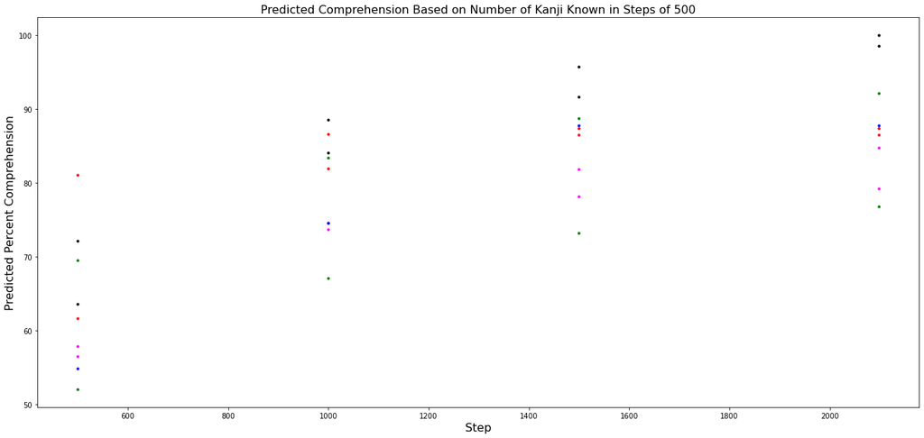

```python
#MAKE SCATTERPLOT OF STEP VS PERCENT KANJI KNOWN LABELED BY SOURCE
import matplotlib.pyplot as graph
graph.figure(figsize=(22,10))
graph.title('Predicted Comprehension Based on Number of Kanji Known in Steps of 500', fontsize = 16)
graph.xlabel('Step', fontsize = 16)
graph.ylabel('Predicted Percent Comprehension', fontsize = 16)
for x,y in comptable.iterrows():
    currcolor = ""
    if y['Source'] == 'News Easy':
        currcolor = "red"
    elif y['Source'] == 'News':
        currcolor = "blue"
    elif y['Source'] == 'Anime':
        currcolor = "green"
    elif y['Source'] == 'Lyrics':
        currcolor = 'black'
    else:
        currcolor = "magenta"
    graph.plot(y['Step'], y['Percent_Kanji_Known'], marker = '.', color = currcolor)
```

The graph above shows predicted comprehension of various sources based on how many kanji one knows. Overall, we see a postivie upward trend indicating the more kanji one knows, the more they will be able to understand. Lets add a linear regression line to this graph to better formalize this trend. To do this, we will need to import LinearRegression from sklearn and numpy.

```
   Step  Predicted Comprehension
0   500                67.470599
1  1000                74.980855
2  1500                82.491111
3  2098                91.473377
```

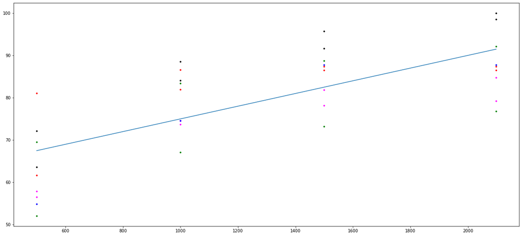

```python
from sklearn.linear_model import LinearRegression
import numpy as np
#calculate linear regression
X = comptable[['Step']]
Y = comptable[['Percent_Kanji_Known']]
regressor = LinearRegression()
regressor.fit(X, Y)
y_pred = regressor.predict(X)
unique_values = y_pred.tolist()
unique_list = np.unique(unique_values)
predtable = pandas.DataFrame(columns = ['Step', 'Predicted Comprehension'])
predtable['Step'] = [500, 1000, 1500, 2098]
predtable['Predicted Comprehension'] = unique_list
print(predtable)

#re-make graph will linear regression line drawn on top
import matplotlib.pyplot as graph
graph.figure(figsize=(22,10))
for x,y in comptable.iterrows():
    currcolor = ""
    if y['Source'] == 'News Easy':
        currcolor = "red"
    elif y['Source'] == 'News':
        currcolor = "blue"
    elif y['Source'] == 'Anime':
        currcolor = "green"
    elif y['Source'] == 'Lyrics':
        currcolor = 'black'
    else:
        currcolor = "magenta"
    graph.plot(y['Step'], y['Percent_Kanji_Known'], marker = '.', color = currcolor)
graph.plot(predtable['Step'], predtable['Predicted Comprehension'])
```

The predicted comprehension of knowing 500 kanji is around 67.47% with each step of 500 afterwards increasing comprehension by 8%, going to ~74.98%, ~82.49%, and finally ~91.47%. So while the first 500 most frequent kanji gives someone the largest boost in comprehension, ~67% comprehension is still not that great as one will only know 2 out of every 3 kanji. The additional steps, while not giving you as much bang for your buck, are necessary to learn to reach higher levels of literacy. Someone who knows the 2098 most frequent kanji will have a predicted comprehension of about 91.47%, which is pretty good, but still not 100%.

## Conclusion

The main takeaway from this tutorial is that while all kanji are not equal, some being used more often than others, it is still very important to learn the the vast majority of the commonly used characters. Learning these characters in order of frequency is a solid strategy that will allow learners of Japanese to quickly increase their comprehension.

The 100 most frequent kanji from the Core10k words list are as follows:

```python
pandas.options.display.max_rows = 100
listcount.head(100)
```

```
日    108
人    102
大     93
見     82
気     80
一     77
不     77
出     76
物     75
手     72
上     71
無     69
生     69
合     66
学     65
行     63
下     59
分     59
中     57
年     57
的     56
引     55
立     55
入     55
国     53
地     52
用     51
間     50
名     49
目     47
取     47
通     46
付     45
書     45
会     45
体     45
発     45
明     44
面     44
事     44
```

[output cut: 46 more lines]

```
身     27
悪     27
知     27
語     27
性     27
後     27
和     27
真     27
高     27
何     27
度     27
感     27
化     26
公     26
dtype: int64
```

If you wish to start studying Japanese, learning these 100 kanji characters first will be extremely beneficial and efficient as you will encounter these kanji on a very frequent basis. Print resources such as kanji dictionaries and online resources such as [WaniKani](https://www.wanikani.com/) are excellent resources to begin learning these kanji on.

## Links for Exact Sources Used in Hypothesis Testing

[News Easy 1: People over 75 years old with driving violations need to have their driving skills examined](https://www3.nhk.or.jp/news/easy/k10013623661000/k10013623661000.html)  
[News Easy 2: We want foreigners to be able to travel to Japan soon](https://www3.nhk.or.jp/news/easy/k10013623131000/k10013623131000.html)  
[News 1: Fierce battle continues in Eastern Ukraine; U.S Defense Minister calls for immediate ceasefire](https://www3.nhk.or.jp/news/html/20220514/k10013625651000.html)  
[News 2: Roughly 70,000 homes in Kanagawa Prefecture which lost power due to a underground power line failure have had their power restored](https://www3.nhk.or.jp/news/html/20220514/k10013625801000.html)  
[Anime 1: Yuru Camp Episode 1](https://animelon.com/video/5f364f40fb929a28fc3dac76)  
[Anime 2: Re:Life Episode 1](https://animelon.com/video/594b0dbb3acd3df56b7e2191)  
[Lyric 1: Only One Yell by 9-tie](https://www.google.com/search?q=only+one+yell+lyrics&rlz=1C1CHBF_enUS902US902&oq=only+o&aqs=chrome.0.69i59l2j69i57j0i20i263i433i512j46i433i512j69i60l3.950j0j7&sourceid=chrome&ie=UTF-8)  
Lyric 2: Fluorite Eye's Song by Yagi, Kairi  
[Amazon Terms and Conditions](https://www.amazon.co.jp/gp/help/customer/display.html/ref=ap_desktop_footer_cou?ie=UTF8&nodeId=643006&language=ja_JP)